# Hands-on Exercise: Interaction analysis in a COVID dataset

EU-SABV Workshop

Author

Pierre-Luc Germain, ETH Zuerich, Switzerland

## 1 Setup

```r
suppressPackageStartupMessages({
  library(SummarizedExperiment) # a basic bioconductor data structure
  library(sechm) # wrapper to plot heatmaps from SummarizedExperiment objects
  library(DESeq2) # Gene differential expression analysis
  library(ggplot2) # plotting
  library(stageR) # staged FDR analysis
})
```

**NoteDifferential analysis package**

To simplify the workshop, we use `DESeq2` to perform the differential analysis across all tutorials. We could have used equally adequate alternatives (e.g. `edgeR` or `limma::voom`), and while the exact commands and field names of the results differ, what we discuss here is equally applicable in any of these packages using (generalized) linear models.

## 2 Dataset

In this example we’ll work with a plasma RNAseq dataset from hospitalized patients with or without COVID-19, taken from Overmyer et al., Cell Syst 2021. The data has been subsetted to simplify the tutorial, and the comparison will be between patients with severe COVID (put under mechanical ventilation) vs non-COVID patients.

The dataset additionally includes patients of both sexes:

```r
se <- readRDS(file.path("..", "hands_on_datasets", "GSE157103_subset.SE.rds"))
table(se$disease, se$gender)
```

```
           female male
  nonCOVID      9    5
  COVID        13   21
```

We first get an overview of the dataset using PCA on variance-stabilized data:

```
using ntop=500 top features by variance
```

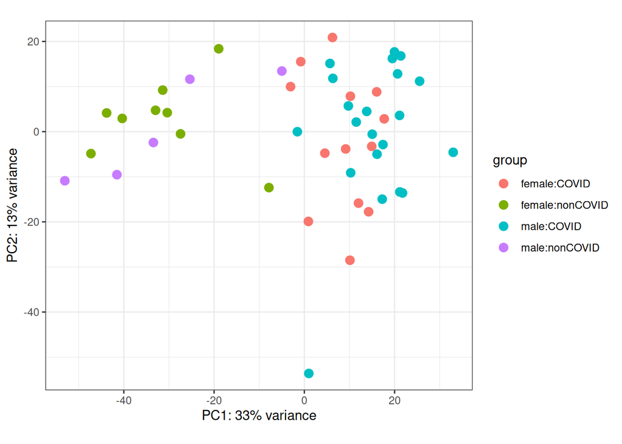

```r
dds <- DESeqDataSet(se, ~gender*disease)
DESeq2::plotPCA(object=vst(dds, blind=TRUE), intgroup=c("gender","disease")) + theme_bw()
```

The results show a clear separation according to disease status, and little global effect of the gender. This indicates that gender is not explaining the largest fractions of variation (among the most variable genes), but does not preclude an impact of gender on specific genes.